# Regression models- Final Project

First, we load dataset MTCARS, in R base package.

```r
library(datasets)
data(mtcars)
```

We note first what variables are in the dataset, and what they measure. mpg = Miles/(US) gallon cyl = Number of cylinders disp = Displacement (cu.in.) hp = Gross horsepower drat = Rear axle ratio wt = Weight (lb/1000) qsec = 1/4 mile time vs = V/S am = Transmission (0 = automatic, 1 = manual) gear = Number of forward gears carb = Number of carburetors

## Exploratory data analysis

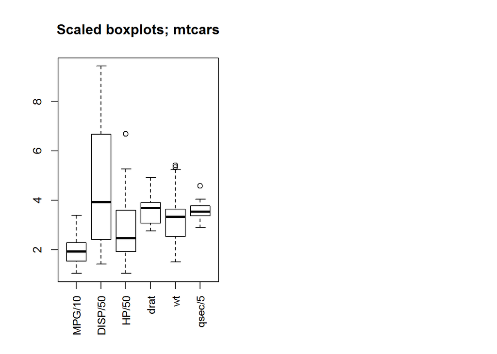

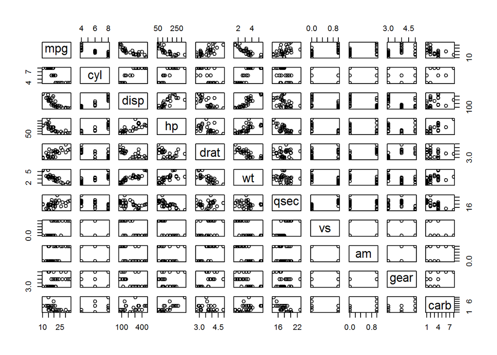

```r
par(mfrow = c(1, 2))
with(mtcars, boxplot(mpg/10, disp/50, hp/50, drat, wt, qsec/5, main = "Scaled boxplots; mtcars"), xlab = "Continuous variable", ylab = "Scale (adjusted to allow simultaneous display")
axisnames <- c("MPG/10", "DISP/50", "HP/50", "drat", "wt", "qsec/5")
axis(1, at = c(1, 2, 3, 4, 5, 6), labels = axisnames, las = 2, cex.axis = 0.9,tck = -0.01)
pairs(mtcars)
```

## Regression model of transmission on fuel efficiency

We construct a simple regression model with transmission as predictor (coded as 1 or 0, where 1 is manual transmission), and fuel economy as outcome (miles achieved per gallon of fuel, MPG).

```r
mtcarsmodel1 <- lm(mpg ~ am, data = mtcars)
summary(mtcarsmodel1)
```

```
##
## Call:
## lm(formula = mpg ~ am, data = mtcars)
##
## Residuals:
##     Min      1Q  Median      3Q     Max
## -9.3923 -3.0923 -0.2974  3.2439  9.5077
##
## Coefficients:
##             Estimate Std. Error t value Pr(>|t|)
## (Intercept)   17.147      1.125  15.247 1.13e-15 ***
## am             7.245      1.764   4.106 0.000285 ***
## ---
## Signif. codes:  0 '***' 0.001 '**' 0.01 '*' 0.05 '.' 0.1 ' ' 1
##
## Residual standard error: 4.902 on 30 degrees of freedom
## Multiple R-squared:  0.3598, Adjusted R-squared:  0.3385
## F-statistic: 16.86 on 1 and 30 DF,  p-value: 0.000285
```

Transmission accounts for 36% of the variance in fuel consumption, which is statistically significantly better than chance (p < .0003). The intercept and slope coefficients show that automatic transmissions achieve 17.147 miles per gallon fuel economy (the reference group), on average, and that manual transmission cars achieve 17.147 + 7.245 = 24.39 miles per gallon fuel economy, on average. These are point estimates, and would be better expressed as 95% Confidence Intervals, for which we use the t.test method in R

```r
attach(mtcars)
y1 <- mpg[am == 0]
y2 <- mpg[am == 1]
x1 <- t.test(y1, mu = 0)
x2 <- t.test(y2, mu = 0)
x1$conf.int
```

```
## [1] 15.29946 18.99528
## attr(,"conf.level")
## [1] 0.95
```

```r
x2$conf.int
```

```
## [1] 20.66593 28.11869
## attr(,"conf.level")
## [1] 0.95
```

from which we can see that the 95% CI for automatic transmission is (15.3, 19), and for manual transmission is (20.67, 28.12). This is evidence that manual transmission yields better fuel economy, but this proposition needs to be tested

## Regression models to test unique effect on fuel efficiency

We have the difficult task of choosing additional variables that might account for the difference we have observed between manual and automatic transmissions. This should be done on theoretical grounds: we argue that automatic transmissions may be found in cars that are heavier in weight, or that have greater engine displacement. We test the relationship between transmission and fuel economy by constructing two baseline regression models with weight or engine displacement as a predictor, and then an augmented model that adds automatic/manual transmission as a variable. We note from the scatterplots, however, that weight and engine displacement appear to be related to MPG in a non-linear manner, and we will therefore inverse-transform fuel efficiency when modeling it.

```r
mtcarsbasemodel1 <- lm(1/mpg ~ wt, data = mtcars)
mtcarsaugmodel1 <- lm(1/mpg ~ wt + am, data = mtcars)
anova(mtcarsbasemodel1, mtcarsaugmodel1)
```

```
## Analysis of Variance Table
##
## Model 1: 1/mpg ~ wt
## Model 2: 1/mpg ~ wt + am
##   Res.Df       RSS Df  Sum of Sq      F Pr(>F)
## 1     30 0.0017402
## 2     29 0.0016465  1 9.3699e-05 1.6504 0.2091
```

```r
mtcarsbasemodel2 <- lm(1/mpg ~ disp, data = mtcars)
mtcarsaugmodel2 <- lm(1/mpg ~ disp + am, data = mtcars)
anova(mtcarsbasemodel2, mtcarsaugmodel2)
```

```
## Analysis of Variance Table
##
## Model 1: 1/mpg ~ disp
## Model 2: 1/mpg ~ disp + am
##   Res.Df       RSS Df  Sum of Sq      F Pr(>F)
## 1     30 0.0018892
## 2     29 0.0018842  1 4.9936e-06 0.0769 0.7836
```

## Further regression models of fuel efficiency

We pursue the question a little further and see whether we can build a model that accounts for fuel consumption on the basis of the observed variables in the dataset mtcars. We reason as follows: cylinders and engine displacement are related, so we consider only engine displacement. Horsepower is likely to be a function of engine displacement, weight, and number of carburetors, so we add number of carburetors but not horsepower (it is an outcome, not a physical property of the engine). A similar argument can be made to reject qsec. We start by testing whether there is evidence to include both weight and displacement in a model, with a test of model difference in a hierarchical sequence.

```r
mtcarsbasemodel3 <- lm(1/mpg ~ wt, data = mtcars)
mtcarsaugmodel3 <- lm(1/mpg ~ wt + disp, data = mtcars)
anova(mtcarsbasemodel3, mtcarsaugmodel3)
```

```
## Analysis of Variance Table
##
## Model 1: 1/mpg ~ wt
## Model 2: 1/mpg ~ wt + disp
##   Res.Df       RSS Df  Sum of Sq      F  Pr(>F)
## 1     30 0.0017402
## 2     29 0.0014226  1 0.00031754 6.4731 0.01654 *
## ---
## Signif. codes:  0 '***' 0.001 '**' 0.01 '*' 0.05 '.' 0.1 ' ' 1
```

This result tells us that we can include weight, and displacement as predictors, they each contribute uniquely to the model.

We now add all remaining variables in our analysis above as a block to our new base model. If the block improves model fit significantly, we will check individual regression coefficients to see if other variables are worth retaining.

```r
mtcarsbasemodel4 <- lm(1/mpg ~ wt + disp, data = mtcars)
mtcarsaugmodel4 <- lm(1/mpg ~ wt + disp + drat + vs + gear + carb, data = mtcars)
anova(mtcarsbasemodel4, mtcarsaugmodel4)
```

```
## Analysis of Variance Table
##
## Model 1: 1/mpg ~ wt + disp
## Model 2: 1/mpg ~ wt + disp + drat + vs + gear + carb
##   Res.Df       RSS Df  Sum of Sq     F Pr(>F)
## 1     29 0.0014226
## 2     25 0.0011914  4 0.00023122 1.213 0.3302
```

The augmented model does not improve the degree of fit (F = 1.21, df = 4,25, p > .33). We therefore accept the baseline model with weight and displacement as predictors, and we look more carefully at it.

```r
summary(mtcarsbasemodel4)
```

```
##
## Call:
## lm(formula = 1/mpg ~ wt + disp, data = mtcars)
##
## Residuals:
##       Min        1Q    Median        3Q       Max
## -0.017062 -0.003494  0.001582  0.004440  0.010852
##
## Coefficients:
##              Estimate Std. Error t value Pr(>|t|)
## (Intercept) 1.353e-02  5.198e-03   2.604  0.01439 *
## wt          8.622e-03  2.796e-03   3.084  0.00445 **
## disp        5.615e-05  2.207e-05   2.544  0.01654 *
## ---
## Signif. codes:  0 '***' 0.001 '**' 0.01 '*' 0.05 '.' 0.1 ' ' 1
##
## Residual standard error: 0.007004 on 29 degrees of freedom
## Multiple R-squared:  0.8299, Adjusted R-squared:  0.8181
## F-statistic: 70.73 on 2 and 29 DF,  p-value: 7.013e-12
```

The model explains 83% of the variance, and each of the coefficients for weight and engine displacement is statistically significantly greater than 0. We need to consider some model diagnostics, and compute these, which are reported in the Appendix. There may be problems with this model. Standardized residuals do not exhibit a cumulative distribution that matched the Normal distribution (there are some points clearly lower than the diagonal line). There also appear to be potential outliers in the various residual plots. However, the dataset is very small (only 32 cases), and it does not seem justified to drop any of the cases for this analysis. An examination of the dfFits and dfBeta statistics might tell us something, but with such a small dataset it does not seem warranted.

## APPENDIX - additional data displays

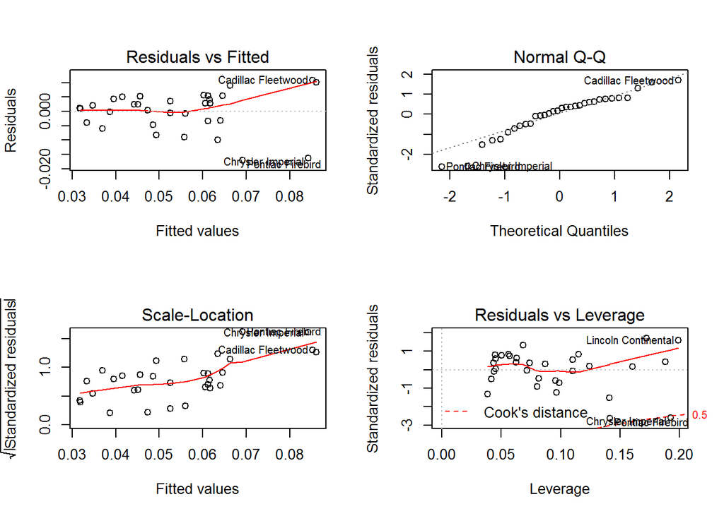

```r
par(mfrow = c(2, 2))
plot(mtcarsbasemodel4)
```